# Consillium Academica

Kevin Andrés Leal Pérez

2023-11-19

# 1 TUTOR AUTOMÁTICO

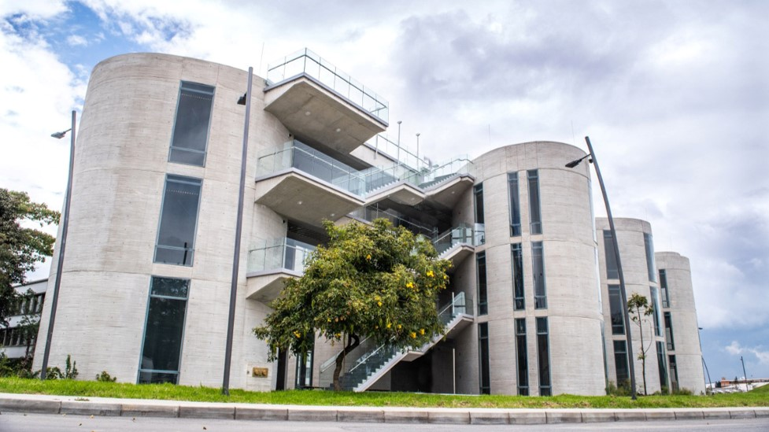

El proyecto tutor automático surge a partir de la iniciativa de la vicedecanatura académica de la Facultad de Ciencias de la Universidad Nacional de Colombia en querer agrupar a los estudiantes de pregrado en los programas curriculares de la facultad, a saber, Biología, Ciencias de la Computación, Estadística, Farmacia, Física, Geología, Matemáticas y Química. El objetivo de esta agrupación es, en un principio, utilizar la información de todos los estudiantes matriculados desde el primer semestre del 2012 hasta el primer semestre de 2022 y así, poder identificar un grupo de estudiantes que se caractericen por tener un desempeño académico inferior al común, cuya consecuencia puede ser la deserción académica o peor aún, la expulsión de la universidad por tener un promedio académico inferior a 3.0 en una escala de calificación de 0.0 a 5.0.

A continuación encontrá el tutorial para crear la base de datos utilizada para realizar el agrupamiento, cuyas filas corresponderán a cada una de las historias académicas de los estudiantes inscritos en los programas curriculares de la Facultad de Ciencias a partir de las bases de datos que registran todas las calificaciones obtenidas en cada una de las asignaturas incritas por todos los estudiantes en cada semestre.

# 2 Cargar las Bases de Datos

Puesto que se debe recopilar la información de las asignaturas a través de las bases de datos existentes para cada uno de los semestres, resulta útil crear la función *Importacion*. Esta función recibirá en como una cadena de caracteres el nombre de un semestre, por ejemplo “2022-1”, y de esta forma primero realizará la importación de las hojas “Historia Academica” e “Insc_Asignat” del excel con el correspondiente nombre, luego se hará la selección únicamente de los estudiantes de pregrado y por último se creará un dataframe que contendrá todas las variables de la segunda hoja y de la primera tomará la información sobre el programa al que pertenece el estudiante. Adicionalmente, se crea una colummna donde se registra el período al que corresponde cada registro.

*Nota:* Para que no se presente ningún error al ejecutar la función se debe asegurar que en todas las bases de datos los nombres de las hojas sean iguales a los mencionados anteriormente.

```r
library(readxl)
library(sqldf)

Importacion <- function(año){

  # Leer las hojas de excel con la historia académica y las asignaturas inscritas
  Hist_Aca <- read_excel(paste0("Bases/",año,".xlsx"), sheet = "Historia Academica", col_types = c("text",
                                   "text", "text", "text", "skip", "text",
                                   "text", "text", "text", "numeric",
                                   "text"))
  colnames(Hist_Aca) <- c("IDG_RIUU","FACULTAD","COD_PLAN","PLAN","CONVOCATORIA","APERTURA",
                          "ACCESO","SUBACCESO","PBM","NODO_INICIO")

  Insc_asig <- read_excel(paste0("Bases/",año,".xlsx"), sheet = "Insc_Asignat", col_types = c("text",
                                   "text", "text", "text", "text",
                                   "text", "text", "numeric", "text",
                                   "numeric", "text", "text", "numeric"))
  colnames(Insc_asig) <- c("IDG_RIUU","COD_ASIGNATURA","ASIGNATURA","GRUPO_ASIGNATURA",
                           "GRUPO_ACT","COD_TIPOLOGIA","TIPOLOGIA","CREDITOS_ASIGNATURA",
                           "UAB_ASIGNATURA","CALIFICACION_NUMERICA","CALIFICACION_ALFABETICA",
                           "TIPO","VECES_VISTA")

  # Seleccionar solo pregrado
  Incorr <- which(Hist_Aca$SUBACCESO=="SUBACCESO")
  Hist_Aca <- Hist_Aca[-Incorr,]

  Posgrado <- which(Hist_Aca$SUBACCESO=="REGULAR DE POSGRADO")
  Hist_Aca <- Hist_Aca[-Posgrado,]

   # En las materias
  Asignaturas <- sqldf("SELECT DISTINCT I.*, H.PLAN, H.COD_PLAN  FROM Hist_Aca H JOIN Insc_asig I
                                        on (H.IDG_RIUU=I.IDG_RIUU)")
  Asignaturas$PERIODO <- rep(año,nrow(Asignaturas))

  return(Asignaturas)
}
```

*Nota:* Hay que tener en cuenta que al utilizar el procedimiento “SELECT DISTINCT” para hacer el cruce entre las dos bases de datos no se da lugar a que la base de datos “Asignaturas” contenga registros duplicados, considerando que en la base de Historia Académica pueden existir registros duplicados.

```r
setwd("C:/Users/kevin/Desktop/Trabajo Grado/Clustering Final")
Años <- paste(rep(2017:2022, rep(2,6)), rep(c(1,2),6), sep = "-")
Años <- c(Años, "2023-1")
Cursos <- NULL

for(i in Años){
  Asigna <- Importacion(i)
  Cursos <- rbind(Cursos,Asigna)
}

head(Cursos)
```

```
##    IDG_RIUU COD_ASIGNATURA                             ASIGNATURA
## 1 008492513        2011170 Intercambio académico otras sedes unal
## 2 012362513        2017792                  Conservación genética
## 3 012362513        2017803                           Etnobotánica
## 4 012362513        2024393    Formulación y gerencia de proyectos
## 5 014322513      1000023-B      Mecánica y ondas para biociencias
## 6 014322513        2015345                      Derecho Ambiental
##   GRUPO_ASIGNATURA GRUPO_ACT COD_TIPOLOGIA                  TIPOLOGIA
## 1                1   Grupo 1             L             LIBRE ELECCIÓN
## 2                1   Grupo 1             T       DISCIPLINAR OPTATIVA
## 3                1   Grupo 1             L             LIBRE ELECCIÓN
## 4                1   Grupo 1             T       DISCIPLINAR OPTATIVA
## 5                3   Grupo 3             B FUNDAMENTACIÓN OBLIGATORIA
## 6                3   Grupo 3             T       DISCIPLINAR OPTATIVA
##   CREDITOS_ASIGNATURA                           UAB_ASIGNATURA
```

[output cut: 20 more lines]

```r
# Identificar los actuales con 2023-1
# BASE_actual <- Importacion("2023-1")
setwd("C:/Users/kevin/Desktop/Trabajo Grado/Clustering Final")
load("Importacion2.RData")
BASE_actual <- Importacion2("2023-2")
actuales <- unique(BASE_actual$IDG_RIUU)
```

# 3 Funciones de Análisis Descriptivo

A continuación se presentan algunas funciones que serán útiles para hacer un análisis descriptivo y exploratorio rápido sobre cualquier base de datos, estas tendrán en cuenta la cantidad de datos faltantes y realizarán un análisis distinto dependiendo de si son variables cuantitativas o cualitativas.

```r
# funciones descriptivas y exploratorias------------------------------------------------------

missings <- function(x) return(sum(is.na(x)))

summ <- function(x){
  x2 <- na.omit(x)
  y <- c(quantile(x2,c(0,0.25,0.5,0.75,1)),length(boxplot.stats(x2)$out),sum(is.na(x)))
  y <- c(y[1:6],100*y[6]/length(x),y[7],100*y[7]/length(x))
  names(y) <- c("Min","Q1","Median","Q3","Max","Outliers","(%)Outliers","Missings","(%)Missings")
  return(round(y,digits=2))
}

summ2 <- function(x){
  x2 <- na.omit(x)
  y <- c(length(unique(x2)),sum(is.na(x)))
  y <- c(y,100*y[2]/length(x))
  names(y) <- c("Levels","Missings","(%)Missings")
  return(round(y,digits=2))
}

eda <- function(datos){
  clases <- sapply(datos,class)
  num <- clases == "numeric" | clases == "integer"
  text <- clases == "character" | clases == "factor"
  out_ <- list()
  if(any(num)){
    cat("\n***Resumen de las variables numéricas***\n\n")
    datos1 <- as.data.frame(datos[,num])
    colnames(datos1) <- colnames(datos)[num]
    out_$numeric <- apply(datos1,2,summ)
    print(out_$numeric)
  }
  if(any(text)){
    cat("\n***Resumen de las variables de texto***\n\n")
    datos2 <- as.data.frame(datos[,text])
    colnames(datos2) <- colnames(datos)[text]
    out_$text <- apply(datos2,2,summ2)
    print(out_$text)
  }
  missings <- apply(datos,1,function(x) return(sum(is.na(x))))
  if(any(missings > 0)){
    cat("\n***Número de missings por individuo***\n\n")
    miss <- as.matrix(table(missings))
    miss <- cbind(miss,round(100*miss/sum(miss),digits=2))
    colnames(miss) <- c("Frequency","%")
    out_$missings <- miss
    print(miss)
  }
  return(invisible(out_))
}
```

Se observan distintas características de la base *Cursos*, la cual contiene todas las asignaturas con sus respectivas calificaciones a lo largo de los semestres y de esta forma se puede empezar el pre-procesamiento de los datos y la limpieza de la información, al igual que el tratamiento a los datos faltantes.

```r
eda(Cursos)
```

```
##
## ***Resumen de las variables numéricas***
##
##             CREDITOS_ASIGNATURA CALIFICACION_NUMERICA VECES_VISTA
## Min                         0.0                  0.00        1.00
## Q1                          3.0                  3.50        1.00
## Median                      3.0                  4.00        1.00
## Q3                          4.0                  4.50        1.00
## Max                        12.0                  5.00        8.00
## Outliers                 5061.0               5312.00     9835.00
## (%)Outliers                 2.9                  3.04        5.63
## Missings                    0.0               6147.00        0.00
## (%)Missings                 0.0                  3.52        0.00
##
## ***Resumen de las variables de texto***
##
##             IDG_RIUU COD_ASIGNATURA ASIGNATURA GRUPO_ASIGNATURA GRUPO_ACT
## Levels          7940           1728       1687           150.00       926
## Missings           0              0          0          1702.00         0
## (%)Missings        0              0          0             0.97         0
##             COD_TIPOLOGIA TIPOLOGIA UAB_ASIGNATURA CALIFICACION_ALFABETICA TIPO
## Levels                  8         8          86.00                    3.00    2
## Missings                0         0         611.00                   20.00    0
## (%)Missings             0         0           0.35                    0.01    0
##             PLAN COD_PLAN PERIODO
## Levels         9        9      13
## Missings       0        0       0
## (%)Missings    0        0       0
##
## ***Número de missings por individuo***
##
##   Frequency     %
## 0    167427 95.81
## 1      6174  3.53
## 2      1153  0.66
```

# 4 Limpieza de la Base

Luego de un ánalisis a los registros de asignaturas que no cuentan con una calificación numérica se descubre que la mayoría de estos corresponden precisamente a las asignaturas de intercambio académico, o asignaturas de nivelación de idiomas, estas materias no son calificadas de forma numérica, únicamente con la calificación alfabética de aprobado o reprobado. Sin embargo, varios de estos registros también corresponden a muchas asignaturas específicas de cada departamento que deberían tener una nota, pero que no la tienen puesto que pueden corresponder a registros duplicados por cambios de profesores en las asignaturas.

Dado que algunas variables que se van a construir más adelante requieren de la calificación numérica y, adicionalmente, los métodos de agrupación utilizan únicamente variables cuantitativas se decide eliminar todos estos registros de la base de datos.

```r
NAss <- which(is.na(Cursos$CALIFICACION_NUMERICA))
Curso_sin_NA <- Cursos[-NAss,]
```

## 4.1 Análisis por Programa

Una vez eliminados estos registros se procede a examinar el comportamiento de la variable de las calificaciones diferenciado por las categorías de otras variables cualitativas como, en primer lugar, el programa curricular.

Se observa que las distribuciones de las calificaciones son muy parecidas entre los programas curriculares, la única diferencia notable es que el programa de Ciencias de la Computación cuenta con un cuartil 75 más alto que los demás programas.

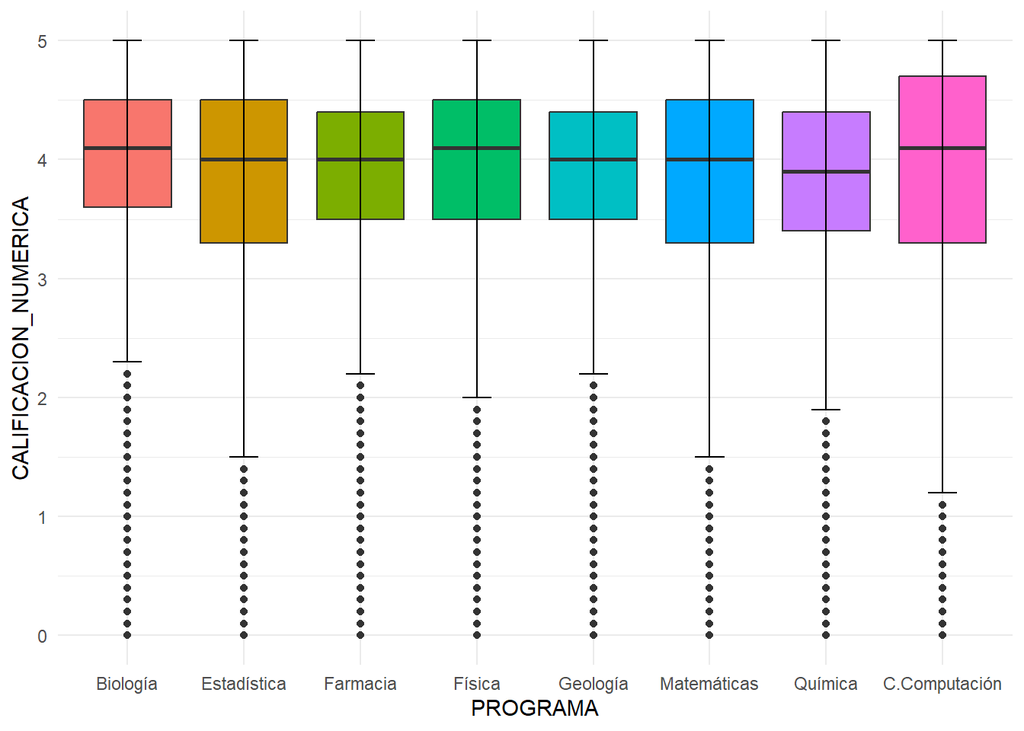

```r
library(ggplot2)

ggplot(Curso_sin_NA, aes(x=COD_PLAN, y=CALIFICACION_NUMERICA, fill=COD_PLAN))+
  geom_boxplot()+
  stat_boxplot(geom = "errorbar", width = 0.25)+
  scale_x_discrete(label= c("Biología", "Estadística", "Farmacia", "Física", "Geología",
                            "Matemáticas", "Química", "C.Computación"))+
  xlab("PROGRAMA")+
  theme_minimal()+
  theme(legend.position = "none")
```

## 4.2 Análisis por Tipología

Al observar la distribución de las calificaciones comparándolas por la tipología de la asignatura se aprecia que las 3 tipologías que tienen notas más altas son primero los trabajos de grado, luego las asignaturas electivas y por último las disciplinares optativas.

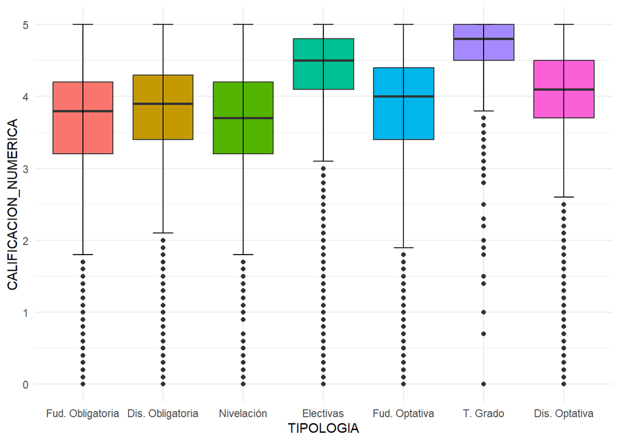

```r
etiquetas = c("Fud. Obligatoria", "Dis. Obligatoria", "Nivelación", "Electivas", "Fud. Optativa", "T. Grado", "Dis. Optativa")

ggplot(Curso_sin_NA, aes(x=COD_TIPOLOGIA, y=CALIFICACION_NUMERICA, fill=COD_TIPOLOGIA))+
  geom_boxplot()+
  stat_boxplot(geom = "errorbar", width = 0.25)+
  scale_x_discrete(label= etiquetas)+
  xlab("TIPOLOGIA")+
  theme_minimal()+
  theme(legend.position = "none")
```

## 4.3 Análisis por Período

Las calificaciones a lo largo de los semestres presentaban un comportamiento muy similar, sin embargo desde el período del 2020-1S cuando inicia la modalidad virtual por la pandemia, desaparecen las notas por debajo de 3.0 por las garantías académicas creadas por la universidad, pero además, las calificaciones mejoran. En todo caso, 2022-2 es el primer semestre luego de la pandemia donde ya no están vigentes estas garantías y se aprecia que la distribución retorna a su comportamiento original.

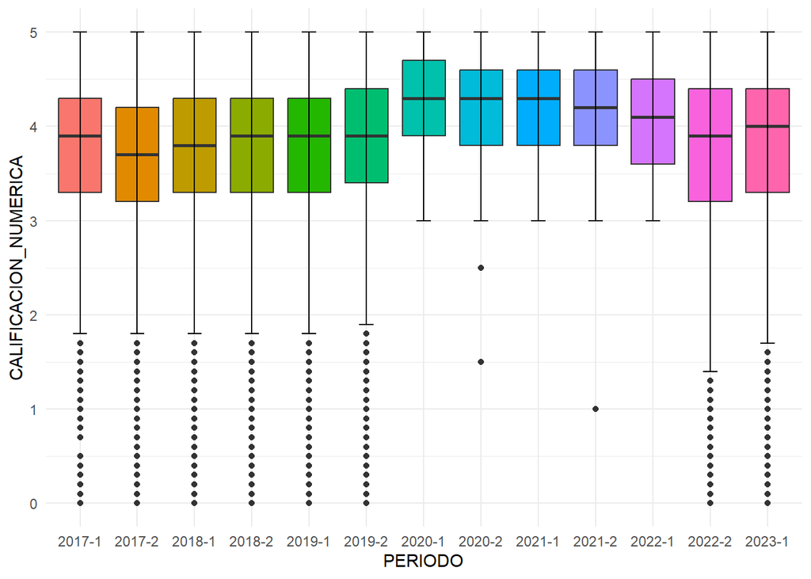

```r
ggplot(Curso_sin_NA, aes(x=PERIODO, y=CALIFICACION_NUMERICA, fill=PERIODO))+
  geom_boxplot()+
  stat_boxplot(geom = "errorbar", width = 0.25)+
  theme_minimal()+
  theme(legend.position = "none")
```

# 5 Construcción de la Base para el Agrupamiento

Esta nueva base contendrá la información correspondiente a cada una de las historias académicas de los estudiantes de la Facultad de Ciencias, es de resaltar que existe la posibilidad de que dos historias académicas distintas pertenezcan a un mismo estudiante puesto que se encuentra inscrito en dos programas curriculares distintos. Esto ocurre cuando el estudiante realiza una doble titulación o realiza un cambio de carrera durante la ventana de tiempo considerada en esta base de datos.

## 5.1 PAPA y Créditos Totales

Las primeras variables que se calculan son el PAPA del estudiante y el total de créditos que ha inscrito considerando solamente las asignaturas presentes en la base de datos de los últimos 6 años.

```r
Estudiantes_TOTAL <- sqldf("SELECT IDG_RIUU AS IDG_RIUU, COD_PLAN AS COD_PLAN,
                      SUM(CREDITOS_ASIGNATURA*CALIFICACION_NUMERICA)/SUM(CREDITOS_ASIGNATURA) AS PAPA_tot,
                      SUM(CREDITOS_ASIGNATURA) AS TOT_CREDITOS
                      FROM Curso_sin_NA
                      GROUP BY IDG_RIUU
                      ORDER BY COD_PLAN, IDG_RIUU")
```

El comportamiento de la distribución del PAPA en los distintos programas curriculares no muestra patrones muy diferentes entre ellos. El único hecho resaltable es las diferencias en las dispersiones de los promedios, puesto que Matemáticas y Ciencias de la Computación parecen tener calificaciones más dispersas, mientras que Biología y Farmacia son más concentradas alrededor de 4.0.

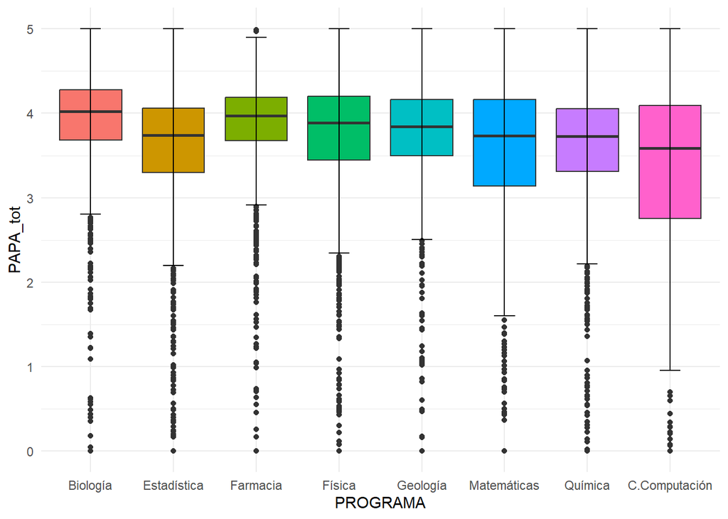

```r
ggplot(Estudiantes_TOTAL, aes(x=COD_PLAN, y=PAPA_tot, fill=COD_PLAN))+
  geom_boxplot()+
  stat_boxplot(geom = "errorbar", width = 0.25)+
  scale_x_discrete(label= c("Biología", "Estadística", "Farmacia", "Física", "Geología", "Matemáticas", "Química", "C.Computación"))+
  xlab("PROGRAMA")+
  theme_minimal()+
  theme(legend.position = "none")
```

## 5.2 Número de Matriculas

```r
matriculas <- sqldf("SELECT IDG_RIUU, COUNT(*) AS NO_MATRICULAS
                    FROM (SELECT DISTINCT IDG_RIUU, PERIODO
                          FROM Curso_sin_NA)
                    GROUP BY IDG_RIUU")

Estud_mat <- sqldf("SELECT ET.*, M.NO_MATRICULAS
                from [Estudiantes_TOTAL] AS ET INNER JOIN [matriculas] AS M
                      on (ET.IDG_RIUU=M.IDG_RIUU)")
```

Es de esperar que la caja de los boxplot se encuentre en los valores inferiores, puesto que se tiene un mayor número de estudiantes que han empezado sus estudios en los últimos 6 años que los que ya han culminado su carrera. Es de resaltar que Ciencias de la Computación es el programa con la mediana más pequeña puesto que es el programa curricular más nuevo de la facultad.

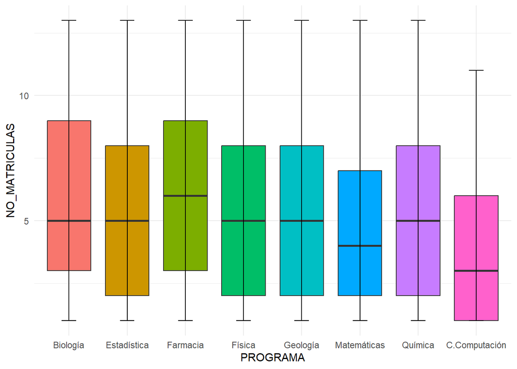

```r
ggplot(Estud_mat, aes(x=COD_PLAN, y=NO_MATRICULAS, fill=COD_PLAN))+
  geom_boxplot()+
  stat_boxplot(geom = "errorbar", width = 0.25)+
  scale_x_discrete(label= c("Biología", "Estadística", "Farmacia", "Física", "Geología", "Matemáticas", "Química", "C.Computación"))+
  xlab("PROGRAMA")+
  theme_minimal()+
  theme(legend.position = "none")
```

## 5.3 Total de Créditos Aprobados

A pesar de que ya se cuenta con una variable que registra la cantidad de créditos inscritos por cada estudiante, es útil crear una nueva variable pero que solo tenga en cuenta los créditos de las asignaturas que efectivamente fueron aprobadas.

```r
Aprobado <- sqldf("SELECT IDG_RIUU, SUM(CREDITOS_ASIGNATURA) AS CREDITOS_AP
                    FROM Curso_sin_NA
                    WHERE CALIFICACION_ALFABETICA ='AP' AND CALIFICACION_NUMERICA >= 3.0
                    GROUP BY IDG_RIUU
                    ORDER BY IDG_RIUU")

Estud_cred <- sqldf("SELECT EM.*, A.CREDITOS_AP
                  FROM [Estud_mat] AS EM LEFT JOIN [Aprobado] AS A
                    ON (EM.IDG_RIUU=A.IDG_RIUU)")

cero <- which(is.na(Estud_cred$CREDITOS_AP))
Estud_cred$CREDITOS_AP[cero] <- 0
```

## 5.4 Avance en el Programa

Esta variable registra el avance en el programa curricular de cada historia académica, sin embargo para realizar este cálculo es necesario dividir el total de créditos aprobados por el total de créditos específicos para cada programa, luego se multiplica por 100 para que el dato esté en forma de porcentaje.

```r
Final <- sqldf("SELECT *, CASE WHEN COD_PLAN='2513' THEN CREDITOS_AP/163
                                WHEN COD_PLAN='2514' THEN CREDITOS_AP/141
                                WHEN COD_PLAN='2515' THEN CREDITOS_AP/185
                                WHEN COD_PLAN='2516' THEN CREDITOS_AP/160
                                WHEN COD_PLAN='2517' THEN CREDITOS_AP/166
                                WHEN COD_PLAN='2518' THEN CREDITOS_AP/140
                                WHEN COD_PLAN='2519' THEN CREDITOS_AP/160
                                ELSE CREDITOS_AP/139 END AS AVANCE
                 FROM Estud_cred")
Final$AVANCE <- round(Final$AVANCE*100,2)
```

## 5.5 Avance Promedio por Semestre

Esta variable es creada como un indicador que refleja la forma en que avanzan los estudiantes en sus respectivos estudios. Consiste de dividir el porcentaje de avance en la carrera por la cantidad de semestres que ha estado matriculado. Puesto que, en general, los programas están planeados para ser terminados en 10 semestres, se espera que para un estudiante con un buen desempeño académico el valor de esta variable esté alrededor del 10%. Si el valor se encuentra por debajo significa que el estudiante avanza de forma lenta, mientras que si está por encima significa que el estudiante está desarrolando sus estudios de forma rápida y terminará antes de lo esperado.

```r
Final$PROM_AVANCE <- round(Final$AVANCE/Final$NO_MATRICULAS,2)
```

Al observar los diagramas de caja, se aprecia que para todos los programas, los cuartiles 1, 2 y 3 se encuentran por debajo de 10, esto demuestra que al menos un 75% de los estudiantes inscritos en todos los departamentos de la Facultad de Ciencias avanzan de forma lenta en sus estudios y están tomando mucho más tiempo del planeado para culminar sus estudios.

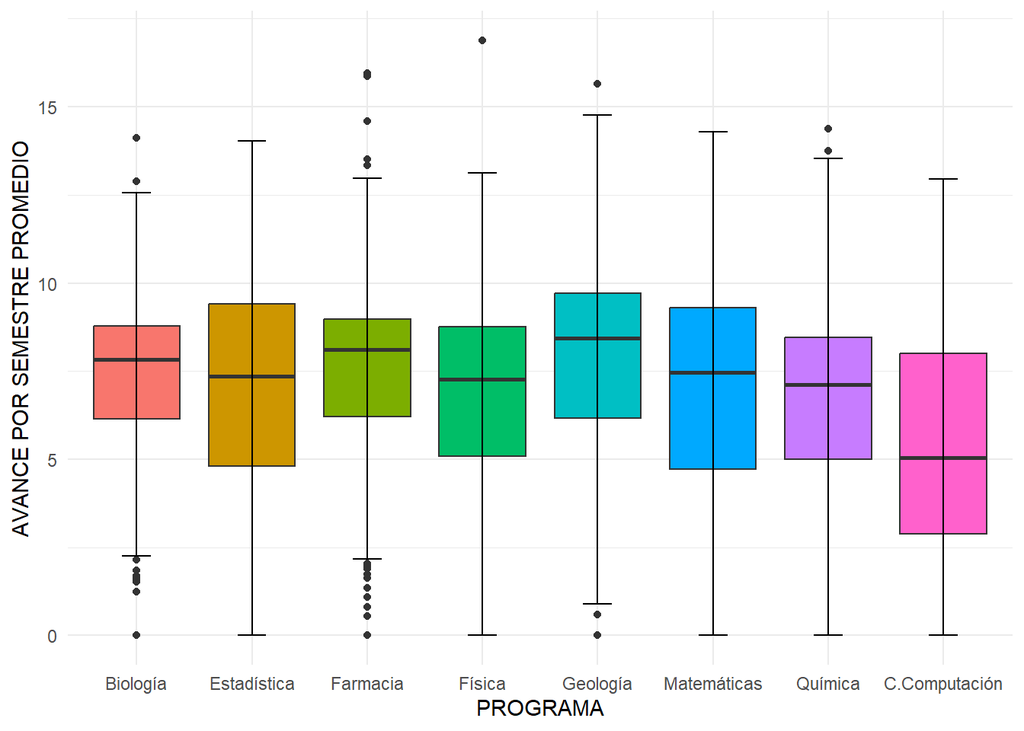

```r
ggplot(Final, aes(x=COD_PLAN, y=PROM_AVANCE, fill=COD_PLAN))+
  geom_boxplot()+
  stat_boxplot(geom = "errorbar", width = 0.25)+
  scale_x_discrete(label= c("Biología", "Estadística", "Farmacia", "Física", "Geología",
                            "Matemáticas", "Química", "C.Computación"))+
  xlab("PROGRAMA")+ ylab("AVANCE POR SEMESTRE PROMEDIO")+
  theme_minimal()+
  theme(legend.position = "none")
```

## 5.6 Cantidad de Asignaturas Perdidas

Esta variable registra la cantidad de asignaturas cuya calificación alfabética es reprobada para cada una de las historias académicas, al menos durante los últimos 6 años.

```r
perdidas <- sqldf("SELECT IDG_RIUU, COUNT(*) AS NO_PERDIDAS
                    FROM (SELECT DISTINCT IDG_RIUU, COD_ASIGNATURA,
                          CALIFICACION_NUMERICA
                          FROM Curso_sin_NA
                          WHERE CALIFICACION_ALFABETICA == 'RE' )
                    GROUP BY IDG_RIUU ")

Final <- sqldf("SELECT F.*, P.NO_PERDIDAS
                from [Final] AS F LEFT JOIN [perdidas] AS P
                      on (F.IDG_RIUU=P.IDG_RIUU)")
Final[is.na(Final$NO_PERDIDAS),9] <- 0
```

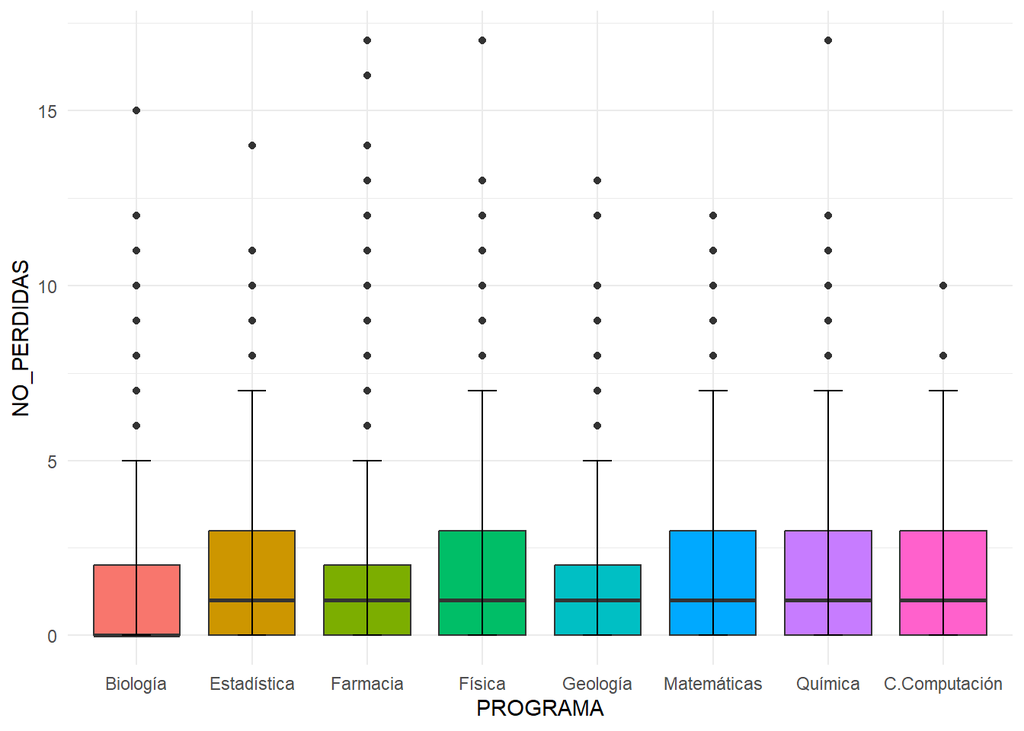

```r
ggplot(Final, aes(x=COD_PLAN, y=NO_PERDIDAS, fill=COD_PLAN))+
  geom_boxplot()+
  stat_boxplot(geom = "errorbar", width = 0.25)+
  scale_x_discrete(label= c("Biología", "Estadística", "Farmacia", "Física", "Geología", "Matemáticas", "Química", "C.Computación"))+
  xlab("PROGRAMA")+
  theme_minimal()+
  theme(legend.position = "none")
```

# 6 Guardar la Base Final

Finalmente, mediante el vector que almacena los identificadores de los estudiantes activos hasta el último semestre, se crea una variable binaria que tomará el valor de 1 si el estudiante se matriculó en el período actual y 0 si no aparece registrado.

```r
indice_actual <- NULL
for (i in 1:length(actuales)) {
  indice_actual <- c(indice_actual, which(Final$IDG_RIUU==actuales[i] ) )
}

Final$ACTIVO <- NA
Final$ACTIVO[indice_actual] <- 1
Final$ACTIVO[which(is.na(Final$ACTIVO))] <- 0
```

Así, se crea un CSV que almacenará toda esta información.

```r
write.csv(Final, "BASE_nueva.csv")
```